# Particulate Matter Course Project

## Introduction

Fine particulate matter (PM2.5) is an ambient air pollutant for which there is strong evidence that it is harmful to human health. In the United States, the Environmental Protection Agency (EPA) is tasked with setting national ambient air quality standards for fine PM and for tracking the emissions of this pollutant into the atmosphere. Approximatly every 3 years, the EPA releases its database on emissions of PM2.5. This database is known as the National Emissions Inventory (NEI). You can read more information about the NEI at the [EPA National Emissions Inventory web site](http://www.epa.gov/ttn/chief/eiinformation.html).

For each year and for each type of PM source, the NEI records how many tons of PM2.5 were emitted from that source over the course of the entire year. The data used in this assignment are from 1999, 2002, 2005, and 2008, and are available [here](https://d396qusza40orc.cloudfront.net/exdata%252Fdata%252FNEI_data.zip).

## Research questions

### Question 1

*Have total emissions from PM2.5 decreased in the United States from 1999 to 2008?*

The following plot shows total PM2.5 emissions from all sources in the U.S., and show a substantial decrease over the course of the evsurvey. PM2.5 emissions in 2008 were approximately half of their 1999 level.

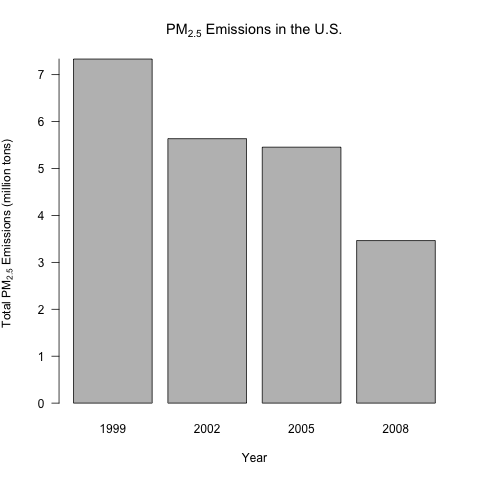

### Question 2

*Have total emissions from PM2.5 decreased in the Baltimore City, Maryland from 1999 to 2008?*

The following plot shows PM2.5 emissions from all sources in the city of Baltimore only. This is done by filtering data on the location code (“24510”) that corresponds to the city of Baltimore. The data show a downward trend, though it is not smoothly downward, as emissions increase in 2005.

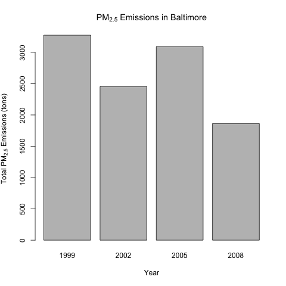

### Question 3

*Of the four types of sources indicated by the type (point, nonpoint, onroad, nonroad) variable, which of these four sources have seen decreases in emissions from 1999–2008 for Baltimore City?*

The following plot shows PM2.5 emissions by source, restricted to the city of Baltimore (location code “24510”). In the plot below, each of the four sources is shown in its own sub-chart. The overall trend in non-road, nonpoint, and on-road emissions is downward. Point source emissions are approximately the same at the start and end of the data, but saw a substantial upward trend during the survey period.

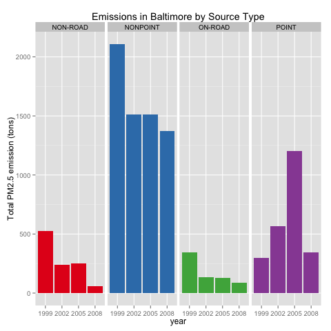

### Question 4

*Across the United States, how have emissions from coal combustion-related sources changed from 1999–2008?*

The following plot shows PM2.5 emissions from coal combustion. In the data, each of the pollution sources in the data is identified with a source code, and only the pollution sources identified with a sector name containing the word “coal” were matched. Once the coal combustion sources were identified, a plot similar to that in question 1 was generated. The data show that coal-related PM2.5 emissions decreased over the measurement period.

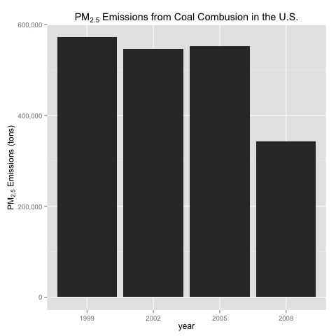

### Question 5

*How have emissions from motor vehicle sources changed from 1999–2008 in Baltimore City?*

The following plot shows motor-vehicle PM2.5 emissions in Baltimore. To analyze only motor vehicles, only on-road emission data is analyzed. To show only Baltimore, the location code “24510” is used as a filter.

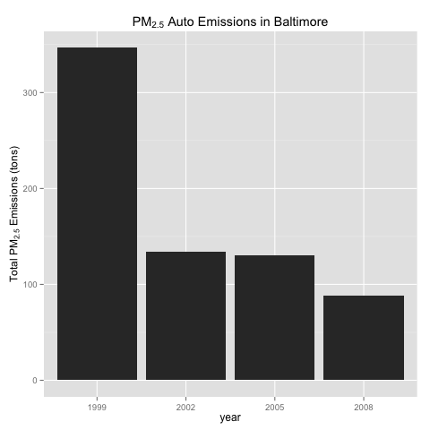

### Question 6

*Compare emissions from motor vehicle sources in Baltimore City with emissions from motor vehicle sources in Los Angeles County, California. Which city has seen greater changes over time in motor vehicle emissions?*

To answer this question, it is not sufficient to look only at the absolute levels of PM2.5 emissions. Los Angeles is a much larger city than Baltimore, and therefore, will see much larger changes in the absolute level of emissions. Therefore, the following plot shows both the absolute level of emissions in Baltimore and Los Angeles, and then shows the relative change by “normalizing” the totals so that they are displayed relative to their maximum. PM2.5 auto emissions in Baltimore fell substantially during the observed period, whereas PM2.5 auto emissions in Los Angeles were relatively constant.

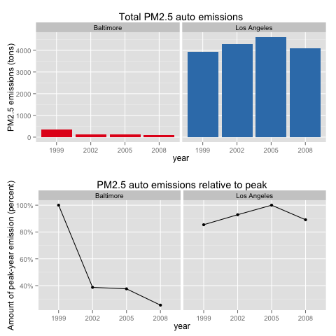